# Unsupervised single-cell clustering with Asymmetric Within-Sample Transformation and per cluster supervised features selection.

Code version: MiMB_part1_clustering_v20261022_2

[S.M. Pagnotta](https://www.researchgate.net/profile/Stefano_Pagnotta) - Dept. of Science and Technology, Università degli Studi del Sannio (Benevento, Italy)

2026-10-22

# Citation

**Pagnotta, S.M. (2024). Unsupervised Single-Cell Clustering with Asymmetric Within-Sample Transformation and Per-Cluster Supervised Features Selection. In: Azad, R.K. (eds) Transcriptome Data Analysis. Methods in Molecular Biology, vol 2812. Humana, New York, NY.**  
- https://doi.org/10.1007/978-1-0716-3886-6_8  
- http://biorxiv.org/content/early/2023/05/21/2023.05.17.541148.abstract

# Home repository

- https://github.com/stefanoMP/MiMB

# License

- [CC BY 4.0](https://creativecommons.org/licenses/by/4.0/): Creative Commons Attribution  
  This license allows reusers to distribute, remix, adapt, and build upon the material in any medium or format, so long as attribution is given to the creator. The license allows for commercial use.

# Overview

This document runs a reusable hierarchical clustering pipeline on pre-normalised single-cell data. The main steps are:

1. **AWST normalisation** and gene filtering via `gene_filter()`
2. **Hierarchical clustering** with Euclidean distance and Ward’s linkage
3. **Calinski-Harabasz index** to guide the choice of the optimal number of clusters
4. **Visualisation** with annotated dendrogram, colour bars (clusterings first, from the largest number of clusters, then the annotation variables) and legends in the top-right corner (clusterings and annotation variables)
5. **Joint analysis of the clusterings and the annotation variables** listed in the `annot_vars` parameter, starting from the joint (two-way) distributions with their marginals, followed by the chi-squared test of independence and the ECA and ECP indices

All key parameters are exposed in the YAML `params` block and can be changed without touching the code, or passed programmatically via `rmarkdown::render()`.

# Global parameters

Active parameters for this run.

| Parameter | Value | Description |
| --- | --- | --- |
| input_rdata | HLIN_EDASeq.RData | Input RData file (must contain ‘ddata’) |
| dataset_label | HLIN | Dataset label shown in plot title |
| hclust_method | ward.D2 | Linkage method for hierarchical clustering |
| cluster_sizes | 5, 7 | Tree cut sizes (number of clusters per partition) |
| annot_vars | patient, class, neuron.subtype | Annotation variables analysed jointly with the clusterings |
| calinski_from | 100 | Lower bound for Calinski index plot |
| calinski_to | 900 | Upper bound for Calinski index plot |
| save_pdf | TRUE | Whether to save the dendrogram as a PDF file |
| pdf_width | 20 | PDF output width (inches) |
| pdf_height | 10 | PDF output height (inches) |
| legend_x_start | 0.76 | Where the legend area starts in the plot (fraction of the plot width, 0-1) |
| calinski_url | https://raw.githubusercontent.com/stefanoMP/functions/main/calinski_20210214.R | URL or local path to the calinski.R script |

# 1 · Helper functions

All reusable functions are defined here and organised into tabs for readability.

## 1.1 Dependencies

```r
suppressPackageStartupMessages({
  library(awst)
  library(dendextend)
  library(RColorBrewer)
})

# Load the calinski function (from URL or local path)
source(params$calinski_url)
```

## 1.1b Helper — `as_param_vector()`

`params$cluster_sizes` may arrive as a string (`"3, 5, 7"`), a list, or an atomic vector depending on how YAML serialises it. This helper always normalises the value into a standard R vector.

```r
#' Coerce cluster_sizes / palettes to an R vector regardless of how
#' YAML passed the value (string, list, or atomic vector).
#'
#' @param x   Raw value from params (e.g. string "3,5,7", list, or vector)
#' @param FUN Coercion function: as.integer (default) or as.character
#' @return Atomic vector of the requested type
as_param_vector <- function(x, FUN = as.integer) {
  if (is.character(x) && length(x) == 1) {
    # e.g. "3, 5, 7" or "c(3, 5, 7)"
    x <- gsub("[c()\\s]", "", x)          # strip c( ) and spaces
    x <- strsplit(x, "[,;]+")[[1]]          # split on comma or semicolon
    x <- x[nzchar(trimws(x))]              # drop empty tokens
  }
  if (is.list(x)) x <- unlist(x)
  FUN(x)
}

#' Coerce a parameter holding NAMES (annotation variables, palettes) to a character
#' vector. Unlike as_param_vector() it never alters the characters of the names.
#'
#' @param x NULL, a character vector, a list, or one string such as "patient, Sex"
#'          or "c('patient', 'Sex')"
#' @return  Character vector (character(0) if x is NULL or empty)
as_name_vector <- function(x) {
  if (is.null(x)) return(character(0))
  if (is.list(x)) x <- unlist(x)
  x <- as.character(x)
  if (length(x) == 1) {
    x <- gsub("^\\s*c\\(|\\)\\s*$|[\"']", "", x)   # "c('a', 'b')" -> "a, b"
    x <- strsplit(x, "[,;]+")[[1]]
  }
  x <- trimws(x)
  x[nzchar(x)]
}

#' Regex matching any of the accepted RData extensions (.RData, .rdata, .rda),
#' case-insensitively.
.RDATA_EXT_REGEX <- "\\.(RData|rdata|rda)$"

#' Derive a new file path by replacing the RData extension (.RData/.rdata/.rda,
#' case-insensitive) of `file` with `suffix`.
#'
#' @param file   Original file path, ending in .RData, .rdata, or .rda
#' @param suffix Replacement string (e.g. "_clustering.RData")
#' @return       Derived path
derive_rdata_path <- function(file, suffix) {
  sub(.RDATA_EXT_REGEX, suffix, file, ignore.case = TRUE)
}

#' Resolve a data file on disk by trying each of the accepted RData
#' extensions (.RData, .rdata, .rda) appended to `base`.
#'
#' @param base Path without extension (e.g. "MyDataset_annotation")
#' @return     First existing path among base+ext, or base+".RData" if none exist
resolve_rdata_file <- function(base) {
  candidates <- paste0(base, c(".RData", ".rdata", ".rda"))
  found <- candidates[file.exists(candidates)]
  if (length(found) > 0) found[1] else candidates[1]
}

#' Return the unique values of `x` that are not valid R colours (NA is ignored).
#' Used to protect rect()/legend() from invalid colour names.
#'
#' @param x Vector of colour names / hex codes
#' @return  Character vector of the invalid values (character(0) if all valid)
.invalid_colors <- function(x) {
  u <- unique(as.character(x))
  u <- u[!is.na(u)]
  u[!vapply(u, function(z) tryCatch({ grDevices::col2rgb(z); TRUE },
                                    error = function(e) FALSE), logical(1))]
}

#' Kelly's 20 chromatic "colours of maximum contrast" (white and black left out),
#' in the order that keeps the first n colours as different from each other as possible.
.CONTRAST_COLORS <- c("#F3C300", "#875692", "#F38400", "#A1CAF1", "#BE0032",
                      "#C2B280", "#848482", "#008856", "#E68FAC", "#0067A5",
                      "#F99379", "#604E97", "#F6A600", "#B3446C", "#DCD300",
                      "#882D17", "#8DB600", "#654522", "#E25822", "#2B3D26")

#' Candidate colours of a palette, in order of preference.
#'
#' @param palette_name "contrast" (high-contrast palette, the default) or the name
#'                     of an RColorBrewer palette
#' @param n            Number of colours needed
#' @return             Character vector of unique colours; when no colour has been
#'                     used yet, the colours to use are the first `n`
.palette_pool <- function(palette_name, n) {
  if (tolower(palette_name) %in% c("contrast", "kelly"))
    return(.CONTRAST_COLORS)
  if (!palette_name %in% rownames(RColorBrewer::brewer.pal.info))
    stop("Unknown palette: '", palette_name,
         "' (use \"contrast\" or an RColorBrewer palette name).")
  maxc <- RColorBrewer::brewer.pal.info[palette_name, "maxcolors"]
  full <- RColorBrewer::brewer.pal(maxc, palette_name)
  own  <- RColorBrewer::brewer.pal(max(3, min(n, maxc)), palette_name)
  unique(c(own[seq_len(min(n, length(own)))], full))
}
```

## 1.2 `prepare_clustering()`

Applies AWST normalisation, filters genes, and computes the hierarchical clustering.

```r
#' @param input_file     Path to RData file containing matrix `ddata`
#' @param output_file    Where to save the output RData (NULL = auto-derived)
#' @param hclust_method  Linkage method for hclust (default: "ward.D2")
#' @param poscount       poscount argument passed to awst()
#' @param full_quantile  full_quantile argument passed to awst()
#' @param force          If TRUE, recompute even if output already exists (default: FALSE)
#' @return Invisible list: hhc, nrow_exprData, ncol_exprData, aCalinski
prepare_clustering <- function(
    input_file,
    output_file    = NULL,
    hclust_method  = "ward.D2",
    poscount       = TRUE,
    full_quantile  = TRUE
    , force          = TRUE
) {
  if (is.null(output_file))
    output_file <- derive_rdata_path(input_file, "_AWST_hclust.RData")

  # -- skip se l'output esiste già e force = FALSE --
  if (file.exists(output_file) && !force) {
    message("⏭  Output already exists, loading from: ", output_file)
    env <- new.env()
    tryCatch(
      load(output_file, envir = env),
      error = function(e) stop(
        "Impossibile leggere l'output esistente '", output_file, "'.\n",
        "  Causa: ", conditionMessage(e), "\n",
        "  Prova a richiamare con force = TRUE per rigenerarlo."
      )
    )
    return(invisible(list(
      hhc           = env$hhc,
      nrow_exprData = env$nrow_exprData,
      ncol_exprData = env$ncol_exprData,
      aCalinski     = env$aCalinski,
      output_file   = output_file
    )))
  }

  # -- verifica che il file di input esista prima di aprirlo --
  if (!file.exists(input_file))
    stop(
      "File di input non trovato: '", input_file, "'.\n",
      "  Directory corrente: ", getwd()
    )

  env <- new.env()
  tryCatch(
    load(input_file, envir = env),
    error = function(e) stop(
      "Impossibile leggere '", input_file, "'.\n",
      "  Causa: ", conditionMessage(e)
    )
  )
  if (!exists("ddata", envir = env))
    stop("'", input_file, "' does not contain an object named 'ddata'.")
  ddata <- env$ddata

  message("→ AWST...")
  exprData <- awst(ddata, poscount = poscount, full_quantile = full_quantile)
  exprData <- gene_filter(exprData)
  message(sprintf("  Dimensions: %d genes x %d cells", nrow(exprData), ncol(exprData)))

  exprData      <- t(exprData)
  nrow_exprData <- nrow(exprData)   # cellule
  ncol_exprData <- ncol(exprData)   # geni

  message("→ Distance matrix + hclust (", hclust_method, ")...")
  ddist <- dist(exprData)
  hhc   <- hclust(ddist, method = hclust_method)

  message("→ Calinski index...")
  aCalinski <- calinski(hhc)

  save(hhc, nrow_exprData, ncol_exprData, aCalinski, file = output_file)
  message("✔  Saved: ", output_file)

  invisible(list(
    hhc           = hhc,
    nrow_exprData = nrow_exprData,
    ncol_exprData = ncol_exprData,
    aCalinski     = aCalinski,
    output_file   = output_file
  ))
}
```

## 1.3 `add_clustering_cut()`

Cuts the tree at *k* clusters and assigns labels and colours.

When several cuts are drawn, a group made of **exactly the same cells** as a group of a cut already coloured keeps the **same colour**. Only the remaining groups receive new colours, taken from the palette of the cut (by default the high-contrast one) and never reused for a different group.

```r
#' @param hhc               hclust object
#' @param clustering.df     Data frame with a 'barcode' column (and the columns of the
#'                          cuts already added, used to find coinciding groups)
#' @param clust.colorCode   Named colour vector already assigned
#' @param no_of_clusters    k for cutree()
#' @param palette_name      RColorBrewer palette name
#' @param colors            Optional colours for this cut; if given (at least k), they
#'                          are used as they are, without inheriting colours
#' @param clustering.prefix Column name prefix (default: "clust")
#' @param short.prefix      Short prefix for cluster labels (default: "c")
#' @return List: updated clustering.df, clust.colorCode, cut height hh
#'         (the cut line is drawn later by .draw_clustering_figure())
add_clustering_cut <- function(
    hhc,
    clustering.df,
    clust.colorCode,
    no_of_clusters,
    palette_name,
    colors            = NULL,
    clustering.prefix = "clust",
    short.prefix      = "c"
) {
  clustering_name     <- paste0(clustering.prefix, no_of_clusters)
  clustering_name.col <- paste0(clustering_name, ".col")

  hh <- (
    hhc$height[length(hhc$height) - no_of_clusters + 2] +
    hhc$height[length(hhc$height) - no_of_clusters + 1]
  ) / 2

  # -- group labels (c<k>1, c<k>2, ...) --
  labels_pool <- c(paste(1:9), letters)
  lab_levels  <- paste0(short.prefix, no_of_clusters, labels_pool)[seq_len(no_of_clusters)]
  grp         <- as.integer(cutree(hhc, k = no_of_clusters))
  grp_lab     <- factor(grp, levels = seq_len(no_of_clusters), labels = lab_levels)

  # -- one colour per group --
  col_of_group <- stats::setNames(rep(NA_character_, no_of_clusters), lab_levels)

  if (!is.null(colors) && length(colors) >= no_of_clusters) {
    # colours explicitly requested by the user: used as they are
    col_of_group[] <- colors[seq_len(no_of_clusters)]
  } else {
    # (1) a group with exactly the same cells as a group of a previous cut
    #     inherits the colour of that group
    prev_cols <- grep(paste0("^", clustering.prefix, "[0-9]+\\.col$"),
                      colnames(clustering.df), value = TRUE)
    prev_cols <- setdiff(prev_cols, clustering_name.col)
    for (pc in prev_cols) {
      prev_lab <- as.character(clustering.df[[sub("\\.col$", "", pc)]])
      prev_col <- as.character(clustering.df[[pc]])
      for (j in seq_len(no_of_clusters)) {
        if (!is.na(col_of_group[j])) next
        in_j <- grp == j
        lv   <- unique(prev_lab[in_j])
        if (length(lv) == 1 && sum(prev_lab == lv) == sum(in_j))
          col_of_group[j] <- prev_col[which(in_j)[1]]
      }
    }

    # (2) remaining groups: new colours from the palette, not used so far
    todo <- which(is.na(col_of_group))
    if (length(todo) > 0) {
      used <- toupper(c(unname(clust.colorCode), col_of_group[!is.na(col_of_group)]))
      pool <- .palette_pool(palette_name, no_of_clusters)
      pool <- pool[!toupper(pool) %in% used]
      if (length(pool) < length(todo)) {       # palette exhausted: add extra colours
        extra <- grDevices::hcl.colors(length(todo) + length(used) + length(pool) + 5,
                                       "Dynamic")
        pool  <- c(pool, extra[!toupper(extra) %in% c(used, toupper(pool))])
      }
      col_of_group[todo] <- pool[seq_along(todo)]
    }
  }

  # -- store labels and colours --
  clustering.df[[clustering_name]]     <- grp_lab
  clustering.df[[clustering_name.col]] <-
    factor(unname(col_of_group[as.character(grp_lab)]),
           levels = unique(unname(col_of_group)))

  clust.colorCode <- c(clust.colorCode, col_of_group)

  list(
    clustering.df   = clustering.df,
    clust.colorCode = clust.colorCode,
    hh              = hh
  )
}
```

## 1.4 Legends

All the legends are drawn together in the **top-right corner** of the dendrogram, side by side: first the clusterings (largest number of clusters first), then the annotation variables. Each legend reports the number of cells for each value.

- The position is computed in device coordinates, so it does not depend on the scale of the plot.
- The text size shrinks automatically (down to a minimum) until all the legends fit on one row; if they still do not fit, they continue on a second row.
- A variable with many values lists only the most frequent ones; a numeric variable with many distinct values is summarised by five values, from the minimum to the maximum.

```r
#' Legend entries of one clustering
#'
#' @param clustering.df   Clustering data frame
#' @param clust.colorCode Named colour vector (cluster label -> colour)
#' @param clustering_name Column name (e.g. "clust7")
#' @return                List(labels, fill)
.cluster_legend_spec <- function(clustering.df, clust.colorCode, clustering_name) {
  tt <- table(clustering.df[[clustering_name]])
  list(labels = paste0(names(tt), " (", tt, ")"),
       fill   = unname(clust.colorCode[names(tt)]))
}

#' Legend entries of one annotation variable
#'
#' @param values     Values of the variable (NULL if only the colour column exists)
#' @param colors     Colour of each cell for that variable
#' @param max_levels Maximum number of entries listed in the legend
#' @return           List(labels, fill), or NULL if there is nothing to show
.annotation_legend_spec <- function(values, colors, max_levels = 10) {
  colors <- as.character(colors)
  if (is.null(values)) values <- colors
  keep   <- !is.na(colors)
  values <- values[keep]
  colors <- colors[keep]
  if (length(colors) == 0) return(NULL)

  # numeric variable with many distinct values: five values from min to max
  if (is.numeric(values) && length(unique(values)) > max_levels) {
    o   <- order(values)
    idx <- o[unique(round(seq(1, length(o), length.out = 5)))]
    return(list(labels = format(signif(values[idx], 3), trim = TRUE),
                fill   = colors[idx]))
  }

  v_chr <- as.character(values)
  v_chr[is.na(v_chr)] <- "NA"
  lev <- if (is.factor(values)) {
    levels(droplevels(values))
  } else if (is.numeric(values)) {
    as.character(sort(unique(values)))
  } else {
    sort(unique(v_chr))
  }
  if (anyNA(values)) lev <- c(lev, "NA")
  tt <- table(factor(v_chr, levels = lev))

  # too many values: keep the most frequent ones (in their natural order)
  n_more <- 0
  if (length(lev) > max_levels) {
    top    <- names(sort(tt, decreasing = TRUE))[seq_len(max_levels)]
    n_more <- length(lev) - max_levels
    lev    <- lev[lev %in% top]
  }

  fill   <- vapply(lev, function(l) names(which.max(table(colors[v_chr == l]))),
                   character(1))
  labels <- paste0(lev, " (", as.integer(tt[lev]), ")")
  if (n_more > 0) {
    labels <- c(labels, paste0("... +", n_more, " more"))
    fill   <- c(fill, "white")
  }
  list(labels = labels, fill = unname(fill))
}

#' Draw all the legends side by side in the top-right corner of the plot
#'
#' @param legend_specs Named list of specs (labels, fill); the names are the titles
#' @param x_left       Left edge of the legend area, in device (ndc) coordinates
#' @param x_right      Right edge of the legend area (ndc)
#' @param y_top        Top edge of the legend area (ndc)
#' @param cex          Starting text size (reduced automatically to fit)
#' @param min_cex      Smallest text size allowed
#' @return             Invisible: the text size used
add_legends <- function(legend_specs, x_left, x_right, y_top,
                        cex = 1, min_cex = 0.55) {
  legend_specs <- Filter(Negate(is.null), legend_specs)
  n <- length(legend_specs)
  if (n == 0) return(invisible(NULL))

  # device (ndc) -> user coordinates of the current plot
  xl    <- grconvertX(x_left,  "ndc", "user")
  xr    <- grconvertX(x_right, "ndc", "user")
  yt    <- grconvertY(y_top,   "ndc", "user")
  gap_x <- 0.03 * (xr - xl)

  # draws (or only measures, with plot = FALSE) legend i with its top-left corner at (x, y)
  draw_one <- function(i, x, y, cex, plot = TRUE) {
    s <- legend_specs[[i]]
    legend(x = x, y = y, legend = s$labels, fill = s$fill,
           title = names(legend_specs)[i], title.adj = 0,
           xjust = 0, yjust = 1, y.intersp = 1, cex = cex,
           bg = "white", box.col = "white", border = "white",
           xpd = TRUE, plot = plot)
  }

  # largest text size for which all the legends fit on one row
  cex_use <- cex
  repeat {
    w <- vapply(seq_len(n),
                function(i) draw_one(i, xl, yt, cex_use, plot = FALSE)$rect$w,
                numeric(1))
    if (sum(w) + gap_x * (n - 1) <= (xr - xl) || cex_use <= min_cex) break
    cex_use <- max(min_cex, cex_use - 0.05)
  }

  # draw side by side; start a new row only if a legend does not fit
  x <- xl; y <- yt; row_h <- 0
  for (i in seq_len(n)) {
    m <- draw_one(i, x, y, cex_use, plot = FALSE)$rect
    if (x > xl && x + m$w > xr) {
      x     <- xl
      y     <- y - 1.05 * row_h
      row_h <- 0
    }
    draw_one(i, x, y, cex_use)
    x     <- x + m$w + gap_x
    row_h <- max(row_h, m$h)
  }
  invisible(cex_use)
}
```

## 1.5 `plot_clustering()`

Main function: loads data, cuts the tree, and draws the figure (dendrogram, colour bars, legends). The figure is drawn by a separate function, so that it can be drawn twice: **always** on the active device, which is the one shown in the report, and also on a PDF file if requested. Results are saved at the end.

Colour bars, **from the top** (closest to the dendrogram) downwards:

1. one bar per clustering, starting from the one with the **largest** number of clusters;
2. one bar per annotation variable (the `*.col` columns of `annotation.df`).

`colored_bars()` stacks the columns from the bottom up (the first column is the lowest bar), so the columns are passed to it in reverse order.

```r
#' Draw the figure on the active graphics device
#'
#' @param hhc            hclust object (heights already normalised to 1)
#' @param main           Plot title
#' @param aCalinski      Calinski index object (see calinski.R)
#' @param cut_heights    Heights of the tree cuts (red lines)
#' @param n_cells        Number of cells
#' @param bar_colors     Data frame of colours; columns are the bars from the bottom
#'                       to the top
#' @param legend_specs   Named list of legend specs (see add_legends())
#' @param legend_x_start Where the legend area starts, as a fraction of the plot
#'                       width (0-1; NULL = 0.76)
#' @param legend_cex     Starting text size of the legends
.draw_clustering_figure <- function(
    hhc, main, aCalinski, calinski_from, calinski_to,
    cut_heights, n_cells, bar_colors, legend_specs,
    legend_x_start = 0.76, legend_cex = 1
) {
  # -- dendrogram --
  plot(hhc, hang = -1, labels = FALSE, xlab = "", sub = "", main = main)

  # Top-right corner of the plot region in device (ndc) coordinates. It is taken
  # right now, before anything else is drawn, so the position of the legends does
  # not depend on changes of the user coordinates made by the functions below.
  usr    <- par("usr")
  if (is.null(legend_x_start)) legend_x_start <- 0.76
  x_from <- usr[1] + legend_x_start * (usr[2] - usr[1])
  corner <- c(x_left  = grconvertX(x_from,  "user", "ndc"),
              x_right = grconvertX(usr[2],  "user", "ndc"),
              y_top   = grconvertY(usr[4],  "user", "ndc"))

  # -- Calinski index and cut lines --
  plot(aCalinski, add = TRUE,
       from = calinski_from, to = calinski_to,
       shift = 0.55, height = 0.35, max_height = 1)
  segments(1, cut_heights, n_cells, cut_heights, col = "red")

  # -- colour bars --
  colored_bars(colors = bar_colors, dend = as.dendrogram(hhc),
               y_scale = 0.1, y_shift = 0.0)

  # -- legends: top-right corner --
  add_legends(legend_specs,
              x_left  = corner[["x_left"]],
              x_right = corner[["x_right"]],
              y_top   = corner[["y_top"]] - 0.005,
              cex     = legend_cex)
  invisible(NULL)
}

#' @param input_file       RData produced by prepare_clustering()
#' @param output_file      Where to save clustering.df (NULL = auto)
#' @param cluster_sizes    Vector of k values (e.g. c(3, 5, 7)); clusterings are always
#'                         drawn from the largest k to the smallest
#' @param palettes         Palettes of the cuts: "contrast" (high-contrast colours) or
#'                         RColorBrewer names. NULL = "contrast" for every cut.
#'                         Each palette stays attached to its own k. Colours already
#'                         used by another group are never reused.
#' @param cluster_colors   Optional named list of colour vectors, one per cut,
#'                         named by clustering column (e.g.
#'                         list(clust3 = c("#E41A1C","#377EB8","#4DAF4A"),
#'                              clust5 = c(...))).
#'                         Entries whose name matches a cut override the palette
#'                         (and the colours inherited from coinciding groups) for
#'                         that cut; all other cuts still use palettes.
#' @param dataset_label    Label shown in the plot title
#' @param calinski_from/to Range for the Calinski index plot
#' @param legend_x_start   Where the legend area starts, as a fraction of the plot
#'                         width (0-1; default 0.76, set in the global parameters)
#' @param legend_cex       Starting text size of the legends (reduced automatically
#'                         until all the legends fit in the top-right corner)
#' @param pdf_file         PDF output path (NULL = do not save). The figure is drawn
#'                         on the PDF and, in any case, on the active device.
#' @param pdf_width/height PDF dimensions in inches
#' @param annot_max_levels Maximum number of entries listed in each annotation legend
#' @param annot_vars       Names of the annotation variables to analyse jointly with the
#'                         clusterings; they are imported into clustering.df even when
#'                         they have no '*.col' colour column
#' @return Invisible list: clustering.df, clust.colorCode, cluster_sizes (in the order
#'         used: largest k first), nrow_exprData, ncol_exprData, annot_vars (the ones
#'         found in annotation.df)
plot_clustering <- function(
    input_file,
    output_file       = NULL,
    cluster_sizes     = c(3, 5),
    palettes          = NULL,
    cluster_colors    = NULL,
    dataset_label     = NULL,
    calinski_from     = 500,
    calinski_to       = 5000,
    legend_x_start    = 0.76,
    legend_cex        = 1,
    pdf_file          = NULL,
    pdf_width         = 20,
    pdf_height        = 10,
    annot_max_levels  = 10,
    annot_vars        = NULL
) {
  # Normalise cluster_sizes (robust to YAML strings like "3, 5, 7")
  cluster_sizes <- as_param_vector(cluster_sizes, as.integer)

  # Palettes: high-contrast colours unless the user asks for something else
  if (is.null(palettes) || length(palettes) == 0) {
    palettes <- rep("contrast", length(cluster_sizes))
  } else {
    palettes <- as_name_vector(palettes)
    if (length(palettes) < length(cluster_sizes)) {
      message("Too few palettes (", length(palettes), " supplied, ",
              length(cluster_sizes), " needed): using \"contrast\" for the others.")
      palettes <- c(palettes,
                    rep("contrast", length(cluster_sizes) - length(palettes)))
    }
  }

  # Largest number of clusters first (first colour bar, first legend);
  # each palette stays attached to its own k.
  ord           <- order(cluster_sizes, decreasing = TRUE)
  cluster_sizes <- cluster_sizes[ord]
  palettes      <- palettes[ord]
  message("Palettes in use: ",
          paste0("k=", cluster_sizes, ":", palettes[seq_along(cluster_sizes)],
                 collapse = ", "))

  env <- new.env()
  load(input_file, envir = env)
  hhc           <- env$hhc
  nrow_exprData <- env$nrow_exprData
  ncol_exprData <- env$ncol_exprData
  aCalinski     <- env$aCalinski

  if (!exists("annotation.df", envir = env, inherits = FALSE)) {
    annotation_file <- resolve_rdata_file(paste0(dataset_label, "_annotation"))
    if (!file.exists(annotation_file))
      stop(
        "'annotation.df' non trovato in '", input_file, "' e file di annotazione ",
        "'", annotation_file, "' non trovato.\n"
      )
    load(annotation_file, envir = env)
    if (!exists("annotation.df", envir = env, inherits = FALSE))
      stop("'", annotation_file, "' non contiene un oggetto chiamato 'annotation.df'.")
    message("annotation.df caricato da: ", annotation_file)
  }
  annotation.df <- env$annotation.df
  annotation.df <- annotation.df[hhc$labels, , drop = FALSE]

  # -- annotation variables: '*.col' columns (colours) and their base variables --
  annot.col_vars <- grep("\\.col$", colnames(annotation.df), value = TRUE)
  bad_cols <- vapply(annot.col_vars,
                     function(n) length(.invalid_colors(annotation.df[[n]])) > 0,
                     logical(1))
  for (n in annot.col_vars[bad_cols])
    cat("NOTE: annotation variable '", n, "' skipped: invalid colour name(s): ",
        paste(head(.invalid_colors(annotation.df[[n]]), 5), collapse = ", "),
        "\n", sep = "")
  annot.col_vars <- annot.col_vars[!bad_cols]
  annot.vars     <- gsub("\\.col$", "", annot.col_vars)

  # -- annotation variables to analyse jointly with the clusterings --
  annot_vars   <- as_name_vector(annot_vars)
  missing_vars <- setdiff(annot_vars, colnames(annotation.df))
  if (length(missing_vars) > 0)
    cat("NOTE: annotation variable(s) not found in annotation.df: ",
        paste(missing_vars, collapse = ", "), "\n", sep = "")
  annot_vars   <- intersect(annot_vars, colnames(annotation.df))

  # -- legend entries of the annotation variables --
  annot_specs <- stats::setNames(
    lapply(seq_along(annot.vars), function(i) {
      v <- annot.vars[i]
      .annotation_legend_spec(
        values     = if (v %in% colnames(annotation.df)) annotation.df[[v]] else NULL,
        colors     = annotation.df[[annot.col_vars[i]]],
        max_levels = annot_max_levels
      )
    }),
    annot.vars
  )

  clustering.df   <- data.frame(row.names = hhc$labels, barcode = hhc$labels)
  clust.colorCode <- NULL

  mmain <- if (!is.null(dataset_label)) {
    paste0(dataset_label, " (", nrow_exprData, " cells / ", ncol_exprData, " genes)")
  } else {
    paste0("(", nrow_exprData, " cells / ", ncol_exprData, " genes)")
  }

  hhc$height <- hhc$height / max(hhc$height)

  clustering.df$reduced <- as.factor(cutree(hhc, k = 500))

  # -- loop over cuts (largest k first: coinciding groups keep the same colour) --
  cut_heights <- numeric(0)
  for (i in seq_along(cluster_sizes)) {
    cname  <- paste0("clust", cluster_sizes[i])
    colors <- if (!is.null(cluster_colors) && cname %in% names(cluster_colors))
                cluster_colors[[cname]] else NULL
    res <- add_clustering_cut(
      hhc             = hhc,
      clustering.df   = clustering.df,
      clust.colorCode = clust.colorCode,
      no_of_clusters  = cluster_sizes[i],
      palette_name    = palettes[i],
      colors          = colors
    )
    clustering.df   <- res$clustering.df
    clust.colorCode <- res$clust.colorCode
    cut_heights     <- c(cut_heights, res$hh)
  }

  # -- data for the colour bars --
  clustering.df <- clustering.df[hhc$labels, , drop = FALSE]

  # import the annotation variables (colours and their base variables)
  annot.import_vars <- union(annot.col_vars,
                             c(annot.vars[annot.vars %in% colnames(annotation.df)],
                               annot_vars))
  if (length(annot.import_vars) > 0)
    clustering.df[annot.import_vars] <- annotation.df[annot.import_vars]

  # bars from the top: clusterings (largest k first), then annotation variables.
  # colored_bars() stacks the columns from the bottom up: reverse order.
  bar_order  <- c(paste0("clust", cluster_sizes, ".col"), annot.col_vars)
  bar_colors <- clustering.df[, rev(bar_order), drop = FALSE]
  colnames(bar_colors) <- gsub("\\.col$", "", colnames(bar_colors))

  # -- legends: clusterings first, then annotation variables --
  legend_specs <- c(
    stats::setNames(
      lapply(cluster_sizes, function(k)
        .cluster_legend_spec(clustering.df, clust.colorCode, paste0("clust", k))),
      paste0("clust", cluster_sizes)
    ),
    annot_specs
  )

  draw_figure <- function() {
    .draw_clustering_figure(
      hhc = hhc, main = mmain, aCalinski = aCalinski,
      calinski_from = calinski_from, calinski_to = calinski_to,
      cut_heights = cut_heights, n_cells = nrow_exprData,
      bar_colors = bar_colors, legend_specs = legend_specs,
      legend_x_start = legend_x_start, legend_cex = legend_cex
    )
  }

  # -- figure: ALWAYS on the active device, so it is shown in the report ... --
  draw_figure()
  dev_report <- as.integer(dev.cur())

  # ... plus a PDF copy, if requested (then back to the device of the report)
  if (!is.null(pdf_file)) {
    pdf(pdf_file, width = pdf_width, height = pdf_height)
    tryCatch(draw_figure(), finally = {
      dev.off()
      if (dev_report %in% dev.list()) dev.set(dev_report)
    })
  }

  # -- save RData --
  if (is.null(output_file))
    output_file <- paste0(dataset_label, "_clustering.RData")
  save(clustering.df, clust.colorCode, file = output_file)
  message("Clustering saved to: ", output_file)

  invisible(list(
    clustering.df   = clustering.df,
    clust.colorCode = clust.colorCode,
    cluster_sizes   = cluster_sizes,
    nrow_exprData   = nrow_exprData,
    ncol_exprData   = ncol_exprData,
    annot_vars      = annot_vars
  ))
}
```

## 1.6 `joint_distribution()`

Joint (two-way) distribution of a clustering and an annotation variable, together with the two marginal distributions (row and column totals). It is the first step of the joint analysis of the clusterings and the annotation variables listed in `annot_vars`.

```r
#' Joint distribution of a clustering and an annotation variable, with marginals
#'
#' @param clustering.df   Clustering data frame (as returned by plot_clustering())
#' @param clustering_name Column with the clustering (e.g. "clust7"): rows of the table
#' @param annot_var       Column with the annotation variable (e.g. "patient"): columns
#' @return List of two tables, both with the marginal distributions in the last row
#'         ("Sum") and in the last column:
#'         counts  = number of cells;
#'         percent = joint relative frequencies, as % of all the cells (the marginals
#'                   are the % of cells of each cluster and of each value of the variable).
#'         Cells with a missing value of the variable are kept (column "NA").
joint_distribution <- function(clustering.df, clustering_name, annot_var) {
  missing_cols <- setdiff(c(clustering_name, annot_var), colnames(clustering.df))
  if (length(missing_cols) > 0)
    stop("Column(s) not found in clustering.df: ", paste(missing_cols, collapse = ", "))

  tab <- table(clustering.df[[clustering_name]], clustering.df[[annot_var]],
               dnn = c(clustering_name, annot_var), useNA = "ifany")
  list(
    counts  = stats::addmargins(tab),
    percent = round(100 * stats::addmargins(prop.table(tab)), 1)
  )
}
```

## 1.7 `entropy_indices()`, `chisq_independence()` and `association_stats()`

Measures of association between a clustering and an annotation variable.

Let $C$ be the confusion matrix that crosses the $N$ categories of the annotation variable (rows, the reference groups) with the $M$ clusters (columns): $c_{ij}$ is the number of cells of category $i$ that fall in cluster $j$, $n_i = \sum_j c_{ij}$ and $m_j = \sum_i c_{ij}$. With $p_{ij} = c_{ij}/n_i$ and $q_{ij} = c_{ij}/m_j$ (and $0 \log 0 = 0$), the Entropy Cluster Purity (ECP) and the Entropy Cluster Accuracy (ECA) of Risso and Pagnotta (2021, Supplementary Material, section 1.9) are

$$ECP = 1 -
\frac{1}{N}\sum_{i=1}^{N}\left(-\frac{1}{\log M}\sum_{j=1}^{M}
p_{ij}\log p_{ij}\right),
\qquad
ECA = 1 - \frac{1}{M}\sum_{j=1}^{M}\left(-\frac{1}{\log N}\sum_{i=1}^{N}
q_{ij}\log q_{ij}\right).$$

ECP is the complement to 1 of the average (normalised) entropy of the distribution of the cells of each category over the clusters; ECA is the complement to 1 of the average (normalised) entropy of the composition of each cluster in terms of the categories. Both are in $[0, 1]$ and reach 1 when $C$ is a square matrix with as many non-zero elements as its dimension. They are not defined (`NA`) when $N$ or $M$ is below 2, because the normalising $\log$ is then 0.

The chi-squared test of independence is the one of `stats::chisq.test()` (Pearson; Yates’ continuity correction only for 2 x 2 tables, as in R). Its approximation is not reliable when many expected counts are small, so the share of expected counts below 5 is reported next to the test.

```r
#' Entropy Cluster Accuracy (ECA) and Entropy Cluster Purity (ECP)
#'
#' Formulas of Risso and Pagnotta (2021), Supplementary Material, section 1.9.
#'
#' @param counts Confusion matrix (or table): rows = the N categories of the reference
#'               variable, columns = the M clusters; counts[i, j] is the number of cells
#'               of category i in cluster j. Empty rows and columns are dropped.
#' @return Named numeric vector c(ECA, ECP); NA if N < 2 or M < 2
entropy_indices <- function(counts) {
  C <- matrix(as.numeric(counts), nrow = nrow(counts))
  C <- C[rowSums(C) > 0, colSums(C) > 0, drop = FALSE]
  N <- nrow(C)                                   # reference groups
  M <- ncol(C)                                   # clusters
  if (N < 2 || M < 2) return(c(ECA = NA_real_, ECP = NA_real_))

  xlogx <- function(p) ifelse(p > 0, p * log(p), 0)    # 0 * log(0) = 0

  p <- C / rowSums(C)                            # p_ij = c_ij / n_i
  q <- sweep(C, 2, colSums(C), "/")              # q_ij = c_ij / m_j

  H_rows <- -rowSums(xlogx(p)) / log(M)          # normalised entropy of each category
  H_cols <- -colSums(xlogx(q)) / log(N)          # normalised entropy of each cluster

  c(ECA = 1 - mean(H_cols), ECP = 1 - mean(H_rows))
}

#' Pearson chi-squared test of independence on a confusion matrix
#'
#' @param counts Confusion matrix (or table); empty rows and columns are dropped
#' @return List: statistic, df, p.value, pct_expected_lt5 (% of the table cells with
#'         expected count < 5); all NA if the table has fewer than 2 rows or columns
chisq_independence <- function(counts) {
  C <- matrix(as.numeric(counts), nrow = nrow(counts))
  C <- C[rowSums(C) > 0, colSums(C) > 0, drop = FALSE]
  if (nrow(C) < 2 || ncol(C) < 2)
    return(list(statistic = NA_real_, df = NA_real_, p.value = NA_real_,
                pct_expected_lt5 = NA_real_))

  ct <- suppressWarnings(stats::chisq.test(C))
  list(statistic        = unname(ct$statistic),
       df               = unname(ct$parameter),
       p.value          = ct$p.value,
       pct_expected_lt5 = 100 * mean(ct$expected < 5))
}

#' Association between a clustering and an annotation variable
#'
#' Chi-squared test of independence, ECA and ECP, computed on the cells that have a
#' non-missing value of both the clustering and the variable.
#'
#' @param clustering.df   Clustering data frame (as returned by plot_clustering())
#' @param clustering_name Column with the clustering (e.g. "clust7"): the clusters
#' @param annot_var       Column with the annotation variable (e.g. "patient"): the
#'                        reference groups
#' @return List: table (data frame Statistic / Value, ready to print), chisq (see
#'         chisq_independence()), ECA, ECP, counts (confusion matrix: rows = categories
#'         of the variable, columns = clusters)
association_stats <- function(clustering.df, clustering_name, annot_var) {
  missing_cols <- setdiff(c(clustering_name, annot_var), colnames(clustering.df))
  if (length(missing_cols) > 0)
    stop("Column(s) not found in clustering.df: ", paste(missing_cols, collapse = ", "))

  ok     <- !is.na(clustering.df[[clustering_name]]) & !is.na(clustering.df[[annot_var]])
  counts <- table(clustering.df[[annot_var]][ok], clustering.df[[clustering_name]][ok])
  counts <- counts[rowSums(counts) > 0, colSums(counts) > 0, drop = FALSE]

  chi <- chisq_independence(counts)
  ei  <- entropy_indices(counts)

  tab <- data.frame(
    Statistic = c("Cells analysed",
                  "Categories of the variable (N)",
                  "Clusters (M)",
                  "Chi-squared statistic",
                  "Degrees of freedom",
                  "Chi-squared p-value",
                  "Expected counts < 5 (% of the table cells)",
                  "ECA (Entropy Cluster Accuracy)",
                  "ECP (Entropy Cluster Purity)"),
    Value = c(format(sum(counts), big.mark = ","),
              format(nrow(counts)),
              format(ncol(counts)),
              formatC(chi$statistic, format = "f", digits = 2, big.mark = ","),
              format(chi$df),
              format.pval(chi$p.value, digits = 3, eps = .Machine$double.eps),
              formatC(chi$pct_expected_lt5, format = "f", digits = 1),
              formatC(ei[["ECA"]], format = "f", digits = 3),
              formatC(ei[["ECP"]], format = "f", digits = 3)),
    stringsAsFactors = FALSE
  )

  list(table = tab, chisq = chi, ECA = ei[["ECA"]], ECP = ei[["ECP"]], counts = counts)
}
```

# 2 · Data preparation

```r
# Derive output path automatically from the input filename
hclust_rdata <- derive_rdata_path(params$input_rdata, "_AWST_hclust.RData")

result_prep <- prepare_clustering(
  input_file    = params$input_rdata,
  output_file   = hclust_rdata,
  hclust_method = params$hclust_method,
  force = TRUE  # uncomment to force recomputation even if output exists
)
```

> **Note:** if `_AWST_hclust.RData` already exists on disk, `prepare_clustering()` loads it directly without re-running AWST or hclust. Pass `force = TRUE` to force recomputation (e.g. after changing the dataset or parameters).

# 3 · Figure 1 — Annotated dendrogram

## Plot

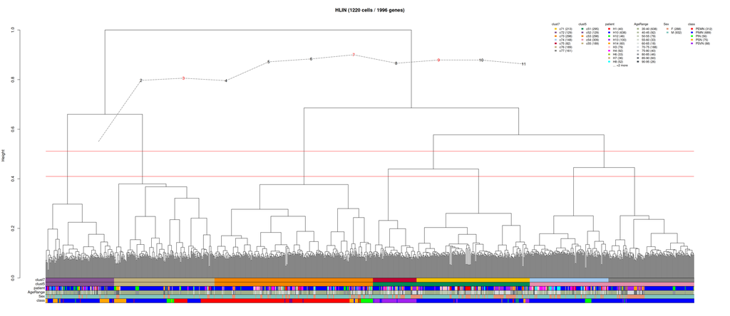

```r
hclust_rdata <- derive_rdata_path(params$input_rdata, "_AWST_hclust.RData")

pdf_out <- if (params$save_pdf) {
  derive_rdata_path(params$input_rdata, "_Figure1.pdf")
} else NULL

result_plot <- plot_clustering(
  input_file    = hclust_rdata,
  cluster_sizes = params$cluster_sizes,
  palettes      = params$palettes,
  dataset_label = params$dataset_label,
  calinski_from = params$calinski_from,
  calinski_to   = params$calinski_to,
  legend_x_start = params$legend_x_start,
  annot_vars    = params$annot_vars,
  pdf_file      = pdf_out,
  pdf_width     = params$pdf_width,
  pdf_height    = params$pdf_height
)
```

**Figure 1.** Unsupervised hierarchical clustering (ward.D2 linkage, Euclidean distance) of **1,220** single-cell transcriptomes from the **HLIN** dataset, based on **1,996** genes selected after Asymmetric Within-Sample Transformation (AWST) normalisation. The Calinski-Harabasz criterion (curve overlaid on the dendrogram) was used to guide the choice of partition granularity. Coloured annotation bars below the dendrogram show the partitions into 7 and 5 clusters (clust7/clust5), obtained by cutting the tree at the corresponding heights; cluster sizes are reported in the summary table below. Additional annotation bars reflect external sample metadata, where available.

## Cluster summary table

```r
if (exists("result_plot")) {
  cdf <- result_plot$clustering.df
  col_names <- paste0("clust", params$cluster_sizes)
  col_names <- col_names[col_names %in% colnames(cdf)]

  for (cn in col_names) {
    tt <- as.data.frame(table(cdf[[cn]]))
    colnames(tt) <- c("Cluster", "N cells")
    cat("\n###", cn, "\n")
    print(knitr::kable(tt, align = "lr"))
  }
}
```

```
##
## ### clust5
##
##
## |Cluster | N cells|
## |:-------|-------:|
## |c51     |     295|
## |c52     |     129|
## |c53     |     298|
## |c54     |     309|
## |c55     |     189|
##
## ### clust7
##
##
## |Cluster | N cells|
## |:-------|-------:|
## |c71     |     213|
## |c72     |     129|
## |c73     |     298|
## |c74     |     148|
## |c75     |      82|
## |c76     |     189|
## |c77     |     161|
```

# 4 · Clusterings and annotation variables

Joint analysis of each clustering with the annotation variables listed in the global parameter `annot_vars`. One tab per variable; for each clustering the analysis includes:

1. the **joint (two-way) distribution** of the clustering (rows) and the variable (columns), reported with its **marginal distributions** (row and column totals, in the `Sum` row and column): first the number of cells, then the same distribution as % of all the cells;
2. the **chi-squared test of independence** between the clustering and the variable, computed on the cells with a non-missing value of the variable; the share of expected counts below 5 is reported because the chi-squared approximation is not reliable when it is large;
3. the **ECA** (Entropy Cluster Accuracy) and **ECP** (Entropy Cluster Purity) indices, computed with the formulas of Risso and Pagnotta (2021, Supplementary Material, section 1.9), taking the categories of the annotation variable as the reference groups (see section 1.7).

## patient

### clust7 and patient

Joint distribution of clust7 (rows) and patient (columns): number of cells, with marginal totals.

|  | H1 | H10 | H12 | H13 | H14 | H3 | H4 | H5 | H6 | H7 | H8 | H9 | Sum |
| --- | --- | --- | --- | --- | --- | --- | --- | --- | --- | --- | --- | --- | --- |
| c71 | 21 | 86 | 1 | 36 | 14 | 25 | 3 | 4 | 7 | 11 | 3 | 2 | 213 |
| c72 | 4 | 71 | 11 | 0 | 4 | 9 | 12 | 4 | 3 | 3 | 5 | 3 | 129 |
| c73 | 6 | 153 | 9 | 24 | 6 | 21 | 28 | 10 | 13 | 8 | 14 | 6 | 298 |
| c74 | 6 | 45 | 0 | 0 | 0 | 18 | 33 | 7 | 7 | 4 | 24 | 4 | 148 |
| c75 | 1 | 34 | 2 | 14 | 5 | 2 | 10 | 0 | 1 | 7 | 3 | 3 | 82 |
| c76 | 2 | 142 | 14 | 1 | 12 | 4 | 6 | 1 | 1 | 3 | 3 | 0 | 189 |
| c77 | 0 | 107 | 9 | 25 | 19 | 0 | 0 | 0 | 1 | 0 | 0 | 0 | 161 |
| Sum | 40 | 638 | 46 | 100 | 60 | 79 | 92 | 26 | 33 | 36 | 52 | 18 | 1220 |

Joint distribution of clust7 (rows) and patient (columns): % of all cells, with marginal percentages.

|  | H1 | H10 | H12 | H13 | H14 | H3 | H4 | H5 | H6 | H7 | H8 | H9 | Sum |
| --- | --- | --- | --- | --- | --- | --- | --- | --- | --- | --- | --- | --- | --- |
| c71 | 1.7 | 7.0 | 0.1 | 3.0 | 1.1 | 2.0 | 0.2 | 0.3 | 0.6 | 0.9 | 0.2 | 0.2 | 17.5 |
| c72 | 0.3 | 5.8 | 0.9 | 0.0 | 0.3 | 0.7 | 1.0 | 0.3 | 0.2 | 0.2 | 0.4 | 0.2 | 10.6 |
| c73 | 0.5 | 12.5 | 0.7 | 2.0 | 0.5 | 1.7 | 2.3 | 0.8 | 1.1 | 0.7 | 1.1 | 0.5 | 24.4 |
| c74 | 0.5 | 3.7 | 0.0 | 0.0 | 0.0 | 1.5 | 2.7 | 0.6 | 0.6 | 0.3 | 2.0 | 0.3 | 12.1 |
| c75 | 0.1 | 2.8 | 0.2 | 1.1 | 0.4 | 0.2 | 0.8 | 0.0 | 0.1 | 0.6 | 0.2 | 0.2 | 6.7 |
| c76 | 0.2 | 11.6 | 1.1 | 0.1 | 1.0 | 0.3 | 0.5 | 0.1 | 0.1 | 0.2 | 0.2 | 0.0 | 15.5 |
| c77 | 0.0 | 8.8 | 0.7 | 2.0 | 1.6 | 0.0 | 0.0 | 0.0 | 0.1 | 0.0 | 0.0 | 0.0 | 13.2 |
| Sum | 3.3 | 52.3 | 3.8 | 8.2 | 4.9 | 6.5 | 7.5 | 2.1 | 2.7 | 3.0 | 4.3 | 1.5 | 100.0 |

Association between clust7 and patient: chi-squared test of independence, ECA and ECP.

| Statistic | Value |
| --- | --- |
| Cells analysed | 1,220 |
| Categories of the variable (N) | 12 |
| Clusters (M) | 7 |
| Chi-squared statistic | 448.87 |
| Degrees of freedom | 66 |
| Chi-squared p-value | <2e-16 |
| Expected counts < 5 (% of the table cells) | 33.3 |
| ECA (Entropy Cluster Accuracy) | 0.365 |
| ECP (Entropy Cluster Purity) | 0.208 |

### clust5 and patient

Joint distribution of clust5 (rows) and patient (columns): number of cells, with marginal totals.

|  | H1 | H10 | H12 | H13 | H14 | H3 | H4 | H5 | H6 | H7 | H8 | H9 | Sum |
| --- | --- | --- | --- | --- | --- | --- | --- | --- | --- | --- | --- | --- | --- |
| c51 | 22 | 120 | 3 | 50 | 19 | 27 | 13 | 4 | 8 | 18 | 6 | 5 | 295 |
| c52 | 4 | 71 | 11 | 0 | 4 | 9 | 12 | 4 | 3 | 3 | 5 | 3 | 129 |
| c53 | 6 | 153 | 9 | 24 | 6 | 21 | 28 | 10 | 13 | 8 | 14 | 6 | 298 |
| c54 | 6 | 152 | 9 | 25 | 19 | 18 | 33 | 7 | 8 | 4 | 24 | 4 | 309 |
| c55 | 2 | 142 | 14 | 1 | 12 | 4 | 6 | 1 | 1 | 3 | 3 | 0 | 189 |
| Sum | 40 | 638 | 46 | 100 | 60 | 79 | 92 | 26 | 33 | 36 | 52 | 18 | 1220 |

Joint distribution of clust5 (rows) and patient (columns): % of all cells, with marginal percentages.

|  | H1 | H10 | H12 | H13 | H14 | H3 | H4 | H5 | H6 | H7 | H8 | H9 | Sum |
| --- | --- | --- | --- | --- | --- | --- | --- | --- | --- | --- | --- | --- | --- |
| c51 | 1.8 | 9.8 | 0.2 | 4.1 | 1.6 | 2.2 | 1.1 | 0.3 | 0.7 | 1.5 | 0.5 | 0.4 | 24.2 |
| c52 | 0.3 | 5.8 | 0.9 | 0.0 | 0.3 | 0.7 | 1.0 | 0.3 | 0.2 | 0.2 | 0.4 | 0.2 | 10.6 |
| c53 | 0.5 | 12.5 | 0.7 | 2.0 | 0.5 | 1.7 | 2.3 | 0.8 | 1.1 | 0.7 | 1.1 | 0.5 | 24.4 |
| c54 | 0.5 | 12.5 | 0.7 | 2.0 | 1.6 | 1.5 | 2.7 | 0.6 | 0.7 | 0.3 | 2.0 | 0.3 | 25.3 |
| c55 | 0.2 | 11.6 | 1.1 | 0.1 | 1.0 | 0.3 | 0.5 | 0.1 | 0.1 | 0.2 | 0.2 | 0.0 | 15.5 |
| Sum | 3.3 | 52.3 | 3.8 | 8.2 | 4.9 | 6.5 | 7.5 | 2.1 | 2.7 | 3.0 | 4.3 | 1.5 | 100.0 |

Association between clust5 and patient: chi-squared test of independence, ECA and ECP.

| Statistic | Value |
| --- | --- |
| Cells analysed | 1,220 |
| Categories of the variable (N) | 12 |
| Clusters (M) | 5 |
| Chi-squared statistic | 201.22 |
| Degrees of freedom | 44 |
| Chi-squared p-value | <2e-16 |
| Expected counts < 5 (% of the table cells) | 18.3 |
| ECA (Entropy Cluster Accuracy) | 0.340 |
| ECP (Entropy Cluster Purity) | 0.137 |

## class

### clust7 and class

Joint distribution of clust7 (rows) and class (columns): number of cells, with marginal totals.

|  | PEMN | PIMN | PIN | PSN | PSVN | Sum |
| --- | --- | --- | --- | --- | --- | --- |
| c71 | 3 | 192 | 4 | 5 | 9 | 213 |
| c72 | 4 | 91 | 2 | 32 | 0 | 129 |
| c73 | 253 | 7 | 24 | 14 | 0 | 298 |
| c74 | 0 | 136 | 12 | 0 | 0 | 148 |
| c75 | 0 | 5 | 0 | 0 | 77 | 82 |
| c76 | 52 | 100 | 13 | 24 | 0 | 189 |
| c77 | 0 | 158 | 1 | 0 | 2 | 161 |
| Sum | 312 | 689 | 56 | 75 | 88 | 1220 |

Joint distribution of clust7 (rows) and class (columns): % of all cells, with marginal percentages.

|  | PEMN | PIMN | PIN | PSN | PSVN | Sum |
| --- | --- | --- | --- | --- | --- | --- |
| c71 | 0.2 | 15.7 | 0.3 | 0.4 | 0.7 | 17.5 |
| c72 | 0.3 | 7.5 | 0.2 | 2.6 | 0.0 | 10.6 |
| c73 | 20.7 | 0.6 | 2.0 | 1.1 | 0.0 | 24.4 |
| c74 | 0.0 | 11.1 | 1.0 | 0.0 | 0.0 | 12.1 |
| c75 | 0.0 | 0.4 | 0.0 | 0.0 | 6.3 | 6.7 |
| c76 | 4.3 | 8.2 | 1.1 | 2.0 | 0.0 | 15.5 |
| c77 | 0.0 | 13.0 | 0.1 | 0.0 | 0.2 | 13.2 |
| Sum | 25.6 | 56.5 | 4.6 | 6.1 | 7.2 | 100.0 |

Association between clust7 and class: chi-squared test of independence, ECA and ECP.

| Statistic | Value |
| --- | --- |
| Cells analysed | 1,220 |
| Categories of the variable (N) | 5 |
| Clusters (M) | 7 |
| Chi-squared statistic | 1,971.54 |
| Degrees of freedom | 24 |
| Chi-squared p-value | <2e-16 |
| Expected counts < 5 (% of the table cells) | 2.9 |
| ECA (Entropy Cluster Accuracy) | 0.686 |
| ECP (Entropy Cluster Purity) | 0.457 |

### clust5 and class

Joint distribution of clust5 (rows) and class (columns): number of cells, with marginal totals.

|  | PEMN | PIMN | PIN | PSN | PSVN | Sum |
| --- | --- | --- | --- | --- | --- | --- |
| c51 | 3 | 197 | 4 | 5 | 86 | 295 |
| c52 | 4 | 91 | 2 | 32 | 0 | 129 |
| c53 | 253 | 7 | 24 | 14 | 0 | 298 |
| c54 | 0 | 294 | 13 | 0 | 2 | 309 |
| c55 | 52 | 100 | 13 | 24 | 0 | 189 |
| Sum | 312 | 689 | 56 | 75 | 88 | 1220 |

Joint distribution of clust5 (rows) and class (columns): % of all cells, with marginal percentages.

|  | PEMN | PIMN | PIN | PSN | PSVN | Sum |
| --- | --- | --- | --- | --- | --- | --- |
| c51 | 0.2 | 16.1 | 0.3 | 0.4 | 7.0 | 24.2 |
| c52 | 0.3 | 7.5 | 0.2 | 2.6 | 0.0 | 10.6 |
| c53 | 20.7 | 0.6 | 2.0 | 1.1 | 0.0 | 24.4 |
| c54 | 0.0 | 24.1 | 1.1 | 0.0 | 0.2 | 25.3 |
| c55 | 4.3 | 8.2 | 1.1 | 2.0 | 0.0 | 15.5 |
| Sum | 25.6 | 56.5 | 4.6 | 6.1 | 7.2 | 100.0 |

Association between clust5 and class: chi-squared test of independence, ECA and ECP.

| Statistic | Value |
| --- | --- |
| Cells analysed | 1,220 |
| Categories of the variable (N) | 5 |
| Clusters (M) | 5 |
| Chi-squared statistic | 1,226.25 |
| Degrees of freedom | 16 |
| Chi-squared p-value | <2e-16 |
| Expected counts < 5 (% of the table cells) | 0.0 |
| ECA (Entropy Cluster Accuracy) | 0.566 |
| ECP (Entropy Cluster Purity) | 0.433 |

## neuron.subtype

### clust7 and neuron.subtype

Joint distribution of clust7 (rows) and neuron.subtype (columns): number of cells, with marginal totals.

|  | PEMN_1 | PEMN_2 | PEMN_3 | PEMN_4 | PIMN_1 | PIMN_2 | PIMN_3 | PIMN_4 | PIMN_5 | PIN_1 | PIN_2 | PSN | PSVN_1 | PSVN_2 | Sum |
| --- | --- | --- | --- | --- | --- | --- | --- | --- | --- | --- | --- | --- | --- | --- | --- |
| c71 | 3 | 0 | 0 | 0 | 91 | 59 | 9 | 21 | 12 | 4 | 0 | 5 | 8 | 1 | 213 |
| c72 | 0 | 0 | 4 | 0 | 1 | 0 | 76 | 14 | 0 | 2 | 0 | 32 | 0 | 0 | 129 |
| c73 | 84 | 91 | 15 | 63 | 3 | 3 | 1 | 0 | 0 | 0 | 24 | 14 | 0 | 0 | 298 |
| c74 | 0 | 0 | 0 | 0 | 5 | 79 | 10 | 7 | 35 | 12 | 0 | 0 | 0 | 0 | 148 |
| c75 | 0 | 0 | 0 | 0 | 0 | 0 | 4 | 0 | 1 | 0 | 0 | 0 | 58 | 19 | 82 |
| c76 | 0 | 2 | 50 | 0 | 1 | 1 | 51 | 46 | 1 | 13 | 0 | 24 | 0 | 0 | 189 |
| c77 | 0 | 0 | 0 | 0 | 57 | 19 | 4 | 29 | 49 | 1 | 0 | 0 | 1 | 1 | 161 |
| Sum | 87 | 93 | 69 | 63 | 158 | 161 | 155 | 117 | 98 | 32 | 24 | 75 | 67 | 21 | 1220 |

Joint distribution of clust7 (rows) and neuron.subtype (columns): % of all cells, with marginal percentages.

|  | PEMN_1 | PEMN_2 | PEMN_3 | PEMN_4 | PIMN_1 | PIMN_2 | PIMN_3 | PIMN_4 | PIMN_5 | PIN_1 | PIN_2 | PSN | PSVN_1 | PSVN_2 | Sum |
| --- | --- | --- | --- | --- | --- | --- | --- | --- | --- | --- | --- | --- | --- | --- | --- |
| c71 | 0.2 | 0.0 | 0.0 | 0.0 | 7.5 | 4.8 | 0.7 | 1.7 | 1.0 | 0.3 | 0 | 0.4 | 0.7 | 0.1 | 17.5 |
| c72 | 0.0 | 0.0 | 0.3 | 0.0 | 0.1 | 0.0 | 6.2 | 1.1 | 0.0 | 0.2 | 0 | 2.6 | 0.0 | 0.0 | 10.6 |
| c73 | 6.9 | 7.5 | 1.2 | 5.2 | 0.2 | 0.2 | 0.1 | 0.0 | 0.0 | 0.0 | 2 | 1.1 | 0.0 | 0.0 | 24.4 |
| c74 | 0.0 | 0.0 | 0.0 | 0.0 | 0.4 | 6.5 | 0.8 | 0.6 | 2.9 | 1.0 | 0 | 0.0 | 0.0 | 0.0 | 12.1 |
| c75 | 0.0 | 0.0 | 0.0 | 0.0 | 0.0 | 0.0 | 0.3 | 0.0 | 0.1 | 0.0 | 0 | 0.0 | 4.8 | 1.6 | 6.7 |
| c76 | 0.0 | 0.2 | 4.1 | 0.0 | 0.1 | 0.1 | 4.2 | 3.8 | 0.1 | 1.1 | 0 | 2.0 | 0.0 | 0.0 | 15.5 |
| c77 | 0.0 | 0.0 | 0.0 | 0.0 | 4.7 | 1.6 | 0.3 | 2.4 | 4.0 | 0.1 | 0 | 0.0 | 0.1 | 0.1 | 13.2 |
| Sum | 7.1 | 7.6 | 5.7 | 5.2 | 13.0 | 13.2 | 12.7 | 9.6 | 8.0 | 2.6 | 2 | 6.1 | 5.5 | 1.7 | 100.0 |

Association between clust7 and neuron.subtype: chi-squared test of independence, ECA and ECP.

| Statistic | Value |
| --- | --- |
| Cells analysed | 1,220 |
| Categories of the variable (N) | 14 |
| Clusters (M) | 7 |
| Chi-squared statistic | 3,257.92 |
| Degrees of freedom | 78 |
| Chi-squared p-value | <2e-16 |
| Expected counts < 5 (% of the table cells) | 20.4 |
| ECA (Entropy Cluster Accuracy) | 0.481 |
| ECP (Entropy Cluster Purity) | 0.629 |

### clust5 and neuron.subtype

Joint distribution of clust5 (rows) and neuron.subtype (columns): number of cells, with marginal totals.

|  | PEMN_1 | PEMN_2 | PEMN_3 | PEMN_4 | PIMN_1 | PIMN_2 | PIMN_3 | PIMN_4 | PIMN_5 | PIN_1 | PIN_2 | PSN | PSVN_1 | PSVN_2 | Sum |
| --- | --- | --- | --- | --- | --- | --- | --- | --- | --- | --- | --- | --- | --- | --- | --- |
| c51 | 3 | 0 | 0 | 0 | 91 | 59 | 13 | 21 | 13 | 4 | 0 | 5 | 66 | 20 | 295 |
| c52 | 0 | 0 | 4 | 0 | 1 | 0 | 76 | 14 | 0 | 2 | 0 | 32 | 0 | 0 | 129 |
| c53 | 84 | 91 | 15 | 63 | 3 | 3 | 1 | 0 | 0 | 0 | 24 | 14 | 0 | 0 | 298 |
| c54 | 0 | 0 | 0 | 0 | 62 | 98 | 14 | 36 | 84 | 13 | 0 | 0 | 1 | 1 | 309 |
| c55 | 0 | 2 | 50 | 0 | 1 | 1 | 51 | 46 | 1 | 13 | 0 | 24 | 0 | 0 | 189 |
| Sum | 87 | 93 | 69 | 63 | 158 | 161 | 155 | 117 | 98 | 32 | 24 | 75 | 67 | 21 | 1220 |

Joint distribution of clust5 (rows) and neuron.subtype (columns): % of all cells, with marginal percentages.

|  | PEMN_1 | PEMN_2 | PEMN_3 | PEMN_4 | PIMN_1 | PIMN_2 | PIMN_3 | PIMN_4 | PIMN_5 | PIN_1 | PIN_2 | PSN | PSVN_1 | PSVN_2 | Sum |
| --- | --- | --- | --- | --- | --- | --- | --- | --- | --- | --- | --- | --- | --- | --- | --- |
| c51 | 0.2 | 0.0 | 0.0 | 0.0 | 7.5 | 4.8 | 1.1 | 1.7 | 1.1 | 0.3 | 0 | 0.4 | 5.4 | 1.6 | 24.2 |
| c52 | 0.0 | 0.0 | 0.3 | 0.0 | 0.1 | 0.0 | 6.2 | 1.1 | 0.0 | 0.2 | 0 | 2.6 | 0.0 | 0.0 | 10.6 |
| c53 | 6.9 | 7.5 | 1.2 | 5.2 | 0.2 | 0.2 | 0.1 | 0.0 | 0.0 | 0.0 | 2 | 1.1 | 0.0 | 0.0 | 24.4 |
| c54 | 0.0 | 0.0 | 0.0 | 0.0 | 5.1 | 8.0 | 1.1 | 3.0 | 6.9 | 1.1 | 0 | 0.0 | 0.1 | 0.1 | 25.3 |
| c55 | 0.0 | 0.2 | 4.1 | 0.0 | 0.1 | 0.1 | 4.2 | 3.8 | 0.1 | 1.1 | 0 | 2.0 | 0.0 | 0.0 | 15.5 |
| Sum | 7.1 | 7.6 | 5.7 | 5.2 | 13.0 | 13.2 | 12.7 | 9.6 | 8.0 | 2.6 | 2 | 6.1 | 5.5 | 1.7 | 100.0 |

Association between clust5 and neuron.subtype: chi-squared test of independence, ECA and ECP.

| Statistic | Value |
| --- | --- |
| Cells analysed | 1,220 |
| Categories of the variable (N) | 14 |
| Clusters (M) | 5 |
| Chi-squared statistic | 2,271.73 |
| Degrees of freedom | 52 |
| Chi-squared p-value | <2e-16 |
| Expected counts < 5 (% of the table cells) | 8.6 |
| ECA (Entropy Cluster Accuracy) | 0.406 |
| ECP (Entropy Cluster Purity) | 0.638 |

# 5 · Rendering from the command line

To regenerate the report on a different dataset without editing the file:

```r
rmarkdown::render(
  "clustering_pipeline.Rmd",
  params = list(
    input_rdata   = "MioDataset_SAVER_EDASeq.RData",
    dataset_label = "MioDataset",
    cluster_sizes = c(4, 7, 10),   # palettes are assigned automatically
    annot_vars    = c("patient"),
    save_pdf      = TRUE
  ),
  output_file = "MioDataset_clustering_report.html"
)
```